# Health Inequalities across Europe: small-area insights from the Euroepan Social Survey

Sara Martino

sara.martino@ntnu.no

Dept. of Mathematical Science, NTNU

## This is joint work with

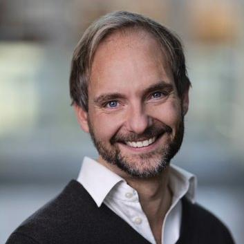

T. Eikemo

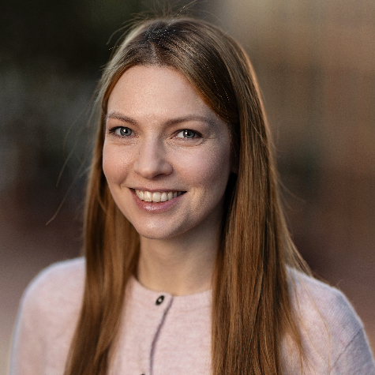

I. Backhaus

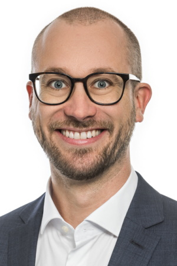

H. Hoven

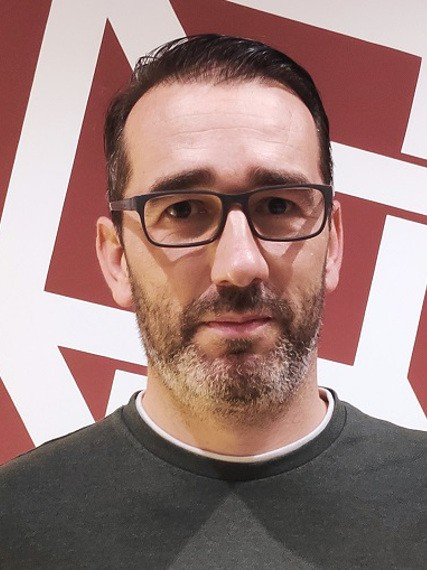

M. Beneito

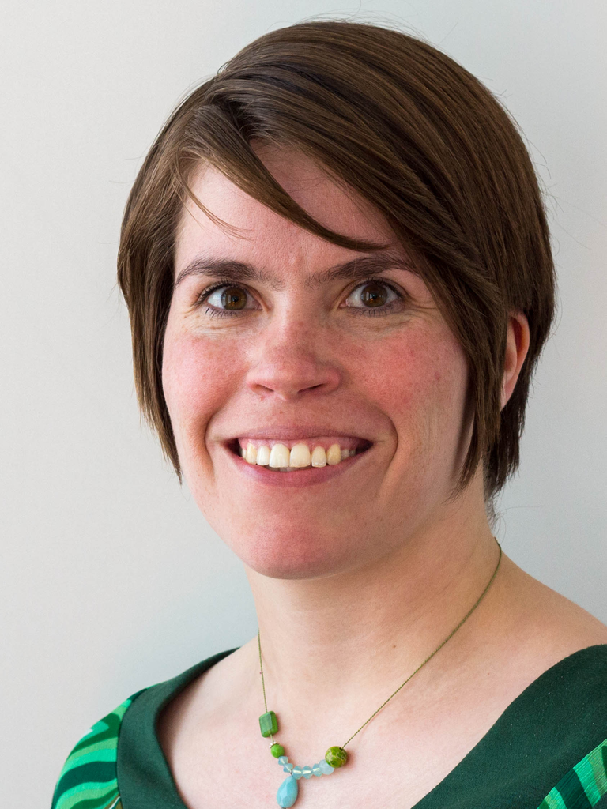

A. Riebler

# The European Social Survey

## The European Social Survey (ESS)

The ESS is designed to measure the values, attitudes, and behavioral patterns of the populations across Europe.

[figure not shown]

- A biennial, cross-national survey conducted in approximately 30 European countries since 2002.
- In each participating country, a minimum of 1,500 respondents are surveyed.
- Respondents are drawn from a probabilistic sample representing the countries’ population aged 15 and above.
- The ESS aims at allowing for cross-country compatibility using harmonized questionnaire design.

## Participating countries

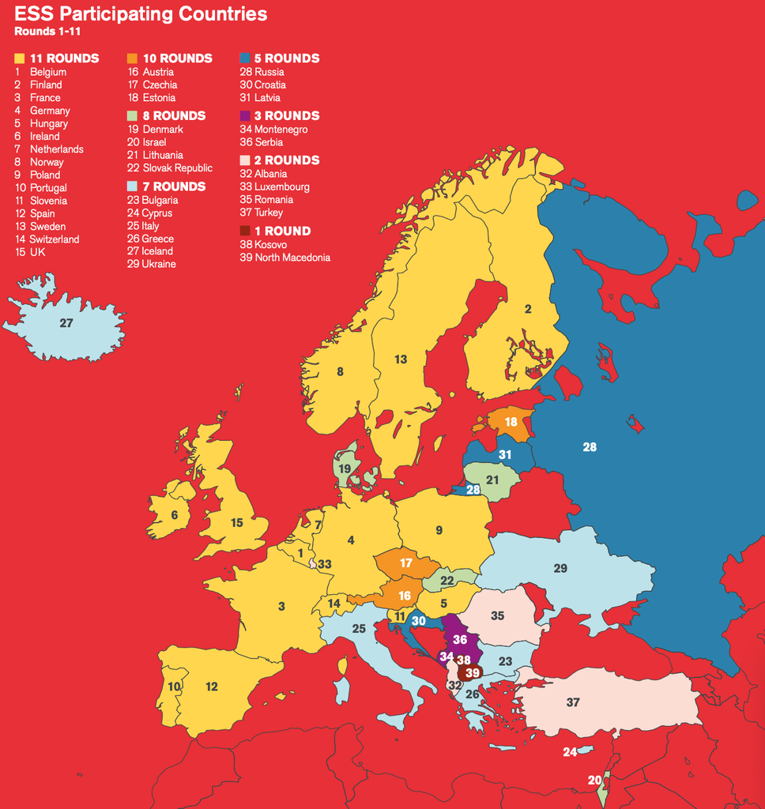

## Focus areas

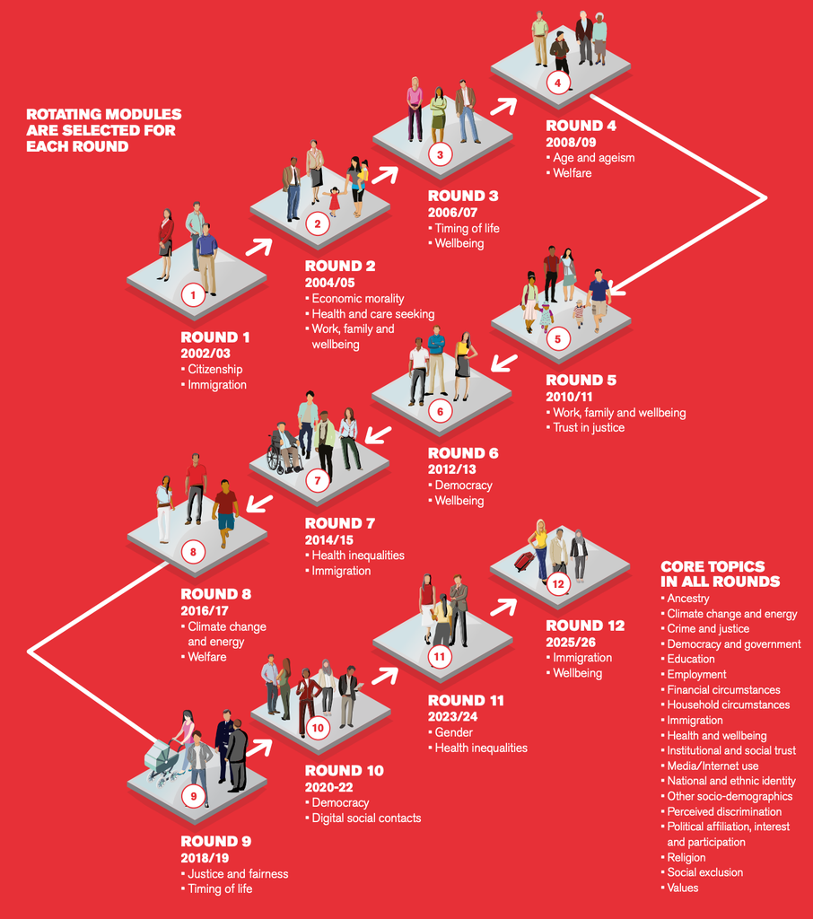

https://forscenter.ch/projects/european-social-survey/

## How about the survey design: Example of Switzerland

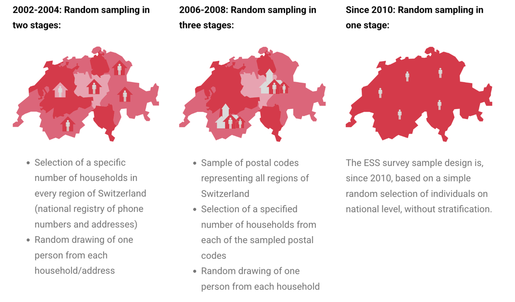

# Motivation

## Education and Health

Education is one of the strongest social determinants of health

Why this matters:

- Education influences health through income, employment, health literacy, and access to resources.
- Understanding these pathways helps explain health inequalities and identify intervention targets.
- Educational improvements may yield long-term health benefits beyond economic returns.
- Evidence can guide policies aimed at improving population health and reducing disparities.

## Why Use Self-Rated Health?

Self-rated health is a simple but powerful measure of overall health and well-being.

- 😀 Captures multiple dimensions of health, including physical, mental, and functional well-being.
- 😀 Strong predictor of future morbidity, healthcare use, and mortality.
- 😀 Easy and inexpensive to collect in large-scale surveys.
- 😀 Available across countries and over time, enabling comparative research.
- 😒 Relies on individual perception and may be influenced by cultural context.

## Self-rated health as a general health indicator

“How is your health in general?”

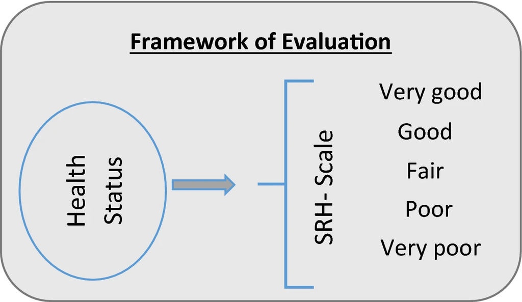

## Goal of the work

- Accumulated evidence has shown **educational inequalities in self-rated health** over time across Europe. $\longrightarrow$ However, there is a lack of understanding on how trends evolve subnationally.
- Monitoring health inequalities at fine spatial scales is crucial for policy planning, but data sparsity and complex survey designs pose challenges.

## What we consider..

Variables that are related both to the sampling/design process and to survey response propensity are:

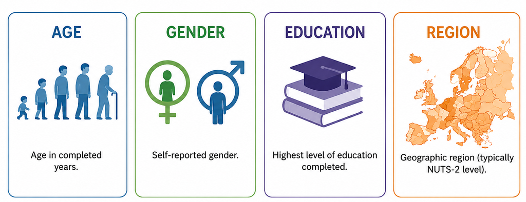

# Data

## Which data do we use?

- We use data from 2010 to 2024 (7 ESS waves) across 195 NUTS-2 regions in up to 31 countries giving us about 40 000 respondents per wave.

Measures

- **Self-rated health**: $\Rightarrow$ Dichotomisation into **1: very good/good**, 0: fair/bad/very bad
- **Gender**: binary
- **Age**: 3 groups: less than $35$, $35$–$55$, older than $55$.
- **Education**: low level, medium, high level.
- **Region**: NUTS2/NUTS1 level information per respondent.

# Statistical model

## Why do we need a model and what should it do?

- Descriptive analysis does not work for small area estimation due to the small sample size $\Rightarrow$ We need a model!
- We would like to borrow strength across time and space $\Rightarrow$ Bayesian hierarchical model with random effects
- In the end we would like to **draw conclusion for the entire population** not just our survey population.

## Our model in 1 page

We use a Bayesian hierarchical model for individual-level data with three key properties:

1. It is a **logistic model** due to the binary outcome variable SRH.
2. Inclusion of random effects for space and time that allow for smoothing by **borrowing strength of neighbouring time points or regions**.
3. **Post-stratification** to get representative estimates at population level.

## Model details

We fitted separate model for males and females.

Let $Y_i$ denote the observed value for individual $i$:

$$\begin{align*}
Y_i \mid \pi_i &\sim \text{Bernoulli}(\pi_i)\\
\text{logit}(\pi_i) &= \mu + u_{\ r_i} + \alpha_{\ t_i} + \phi_{\ c_i} +\text{fixed effects} + \text{interaction effects}\\
\end{align*}$$

- $\bf{u}$ follows a BYM2 model over the region $r$.
- $\bf{\alpha}$ follows a RW2 model over the ESS wave $t$.
- $\bf{\phi}$ is an iid effect for country $c$.
- Fixed effects: Age and education
- Interaction effects to adjust for the survey design as recommend by Gelman et al.

## Multilevel Regression and Post-Stratification (MRP)

We are interested in prevalence estimates at the population level.

MRP is a two stages:

1. Use a model to estimate probabilities $\pi_i$
   - These probabilities reflect the survey population

## Multilevel Regression and Post-Stratification (MRP)

We are interested in prevalence estimates at the population level.

MRP is a two stages:

1. Use a model to estimate probabilities $\pi_i$
   - These probabilities reflect the survey population
2. Weight model predictions for different subgroups by the actual frequency of these subgroups. This idea can be expressed as:

$$\hat{\pi}^{MRP}_s = \frac{\sum_{i\in s} N_j \hat{\pi}_j}{\sum_{i\in s} N_j }$$

- These probabilities reflect the actual population
- We need to know the population in each of the cells se are interested in (GENDER$\times$AGE$\times$EDUCATION$\times$NUTS)

## Population in Europe

We need population counts stratified by gender, age, education and NUTS.

Can be problematic as NUTS regions have changed over time

- We use $1\times 1$ Km population estimates from WorldPop stratified by **gender** and **age groups**.
- Those estimates were aggregated to the regions of our study (NUTS2).
- To get estimates stratified by education, we applied a multinomial model incorporating survey weights from the ESS leading to a pseudo-likelihood.

[figure not shown]

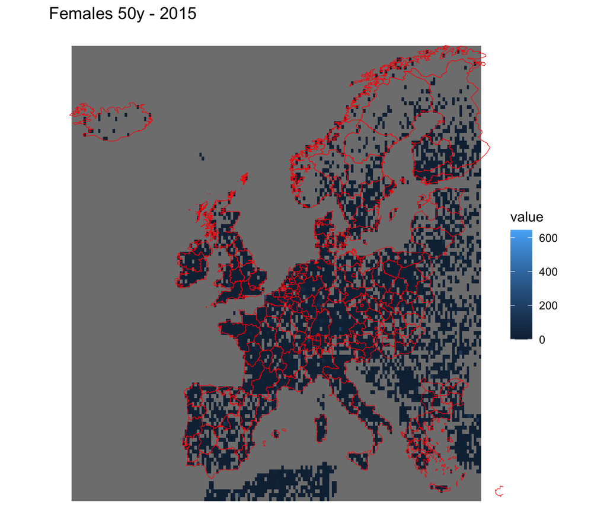

https://www.worldpop.org/

## Uncertainty quantification

- We use a Monte Carlo approach to compute uncertainties for posterior marginal estimates adjusting for how many people we have in the strata.
- We also account for uncertainty in the population estimates that we need for MRP

# Results

## Posterior probability of reporting good health - by education

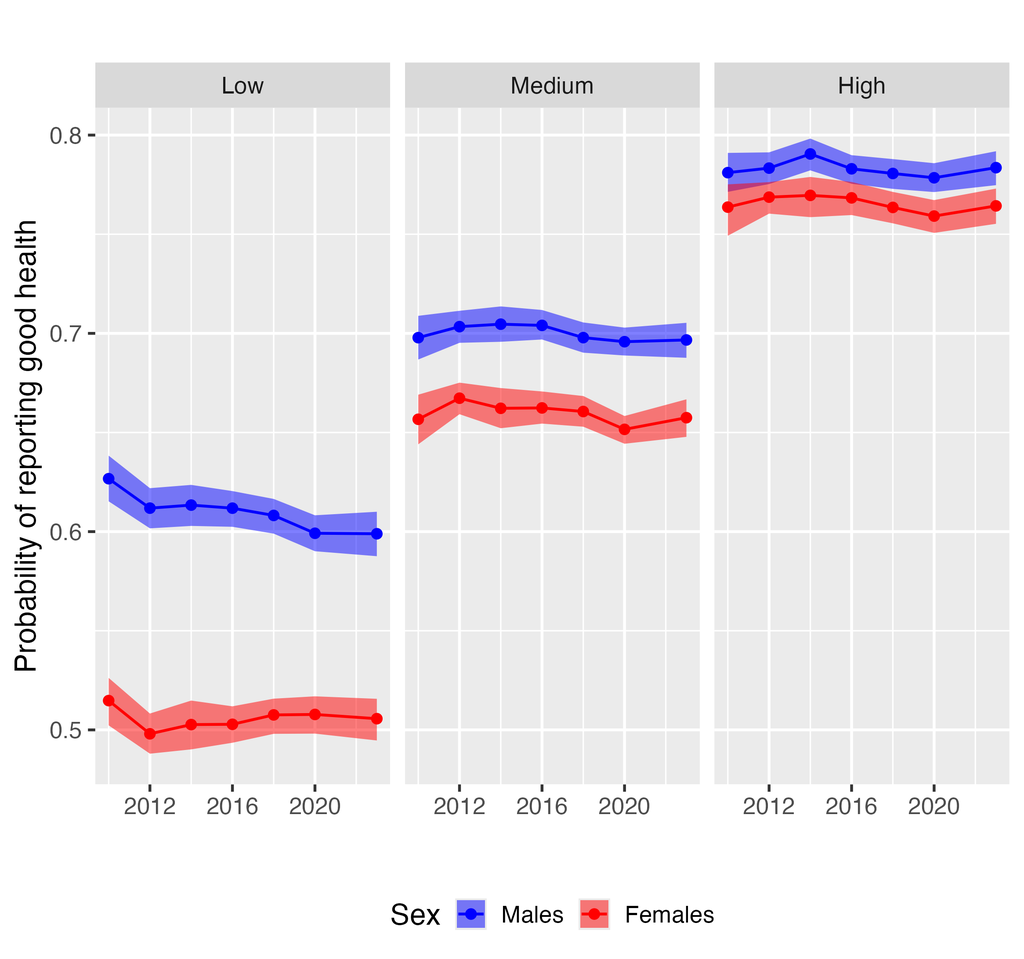

## Posterior probability of reporting good health - by age

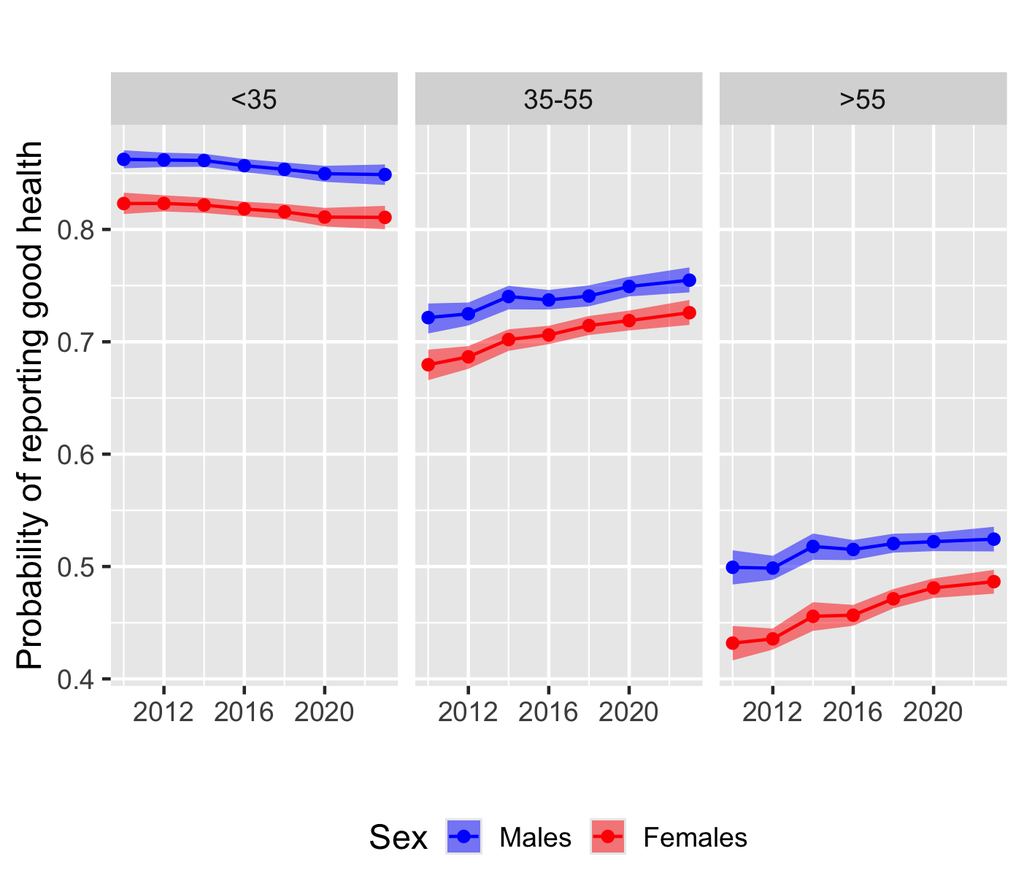

## Mean sex difference in reporting good SRH

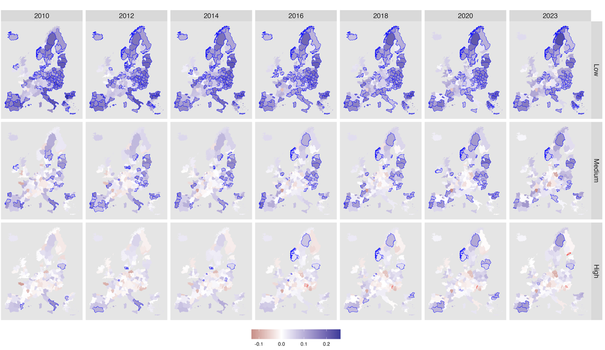

# Discussion

## Discussion I

This study intends to make an empirical and methodological contribution to **understanding inequalities in self‑rated health trends in Europe** by presenting systematic **sub-national analyses** over time disaggregated by two prominent determinants of health: gender and education.

- modest improvements in self-rated health over time, with gains concentrated among women
- **substantial within-country heterogeneity** emerges, underscoring the importance of small-area analyses.

**Of note**, we assessed how well we adjust for the survey design in our model by regressing the survey weights on the control variable and their interactions finding that we explain about $70\%$ of the design.

## Discussion II

More in general:

- The ESS allows to investigate health inequity across Europe along different variables.
- Multi-country comparisons are encouraged.
- Challenges include that there are not so many respondents which complicates spatial analysis and the survey design has to be adjusted for.

## Thank you!

[figure not shown]

## Posterior probability of reporting good health

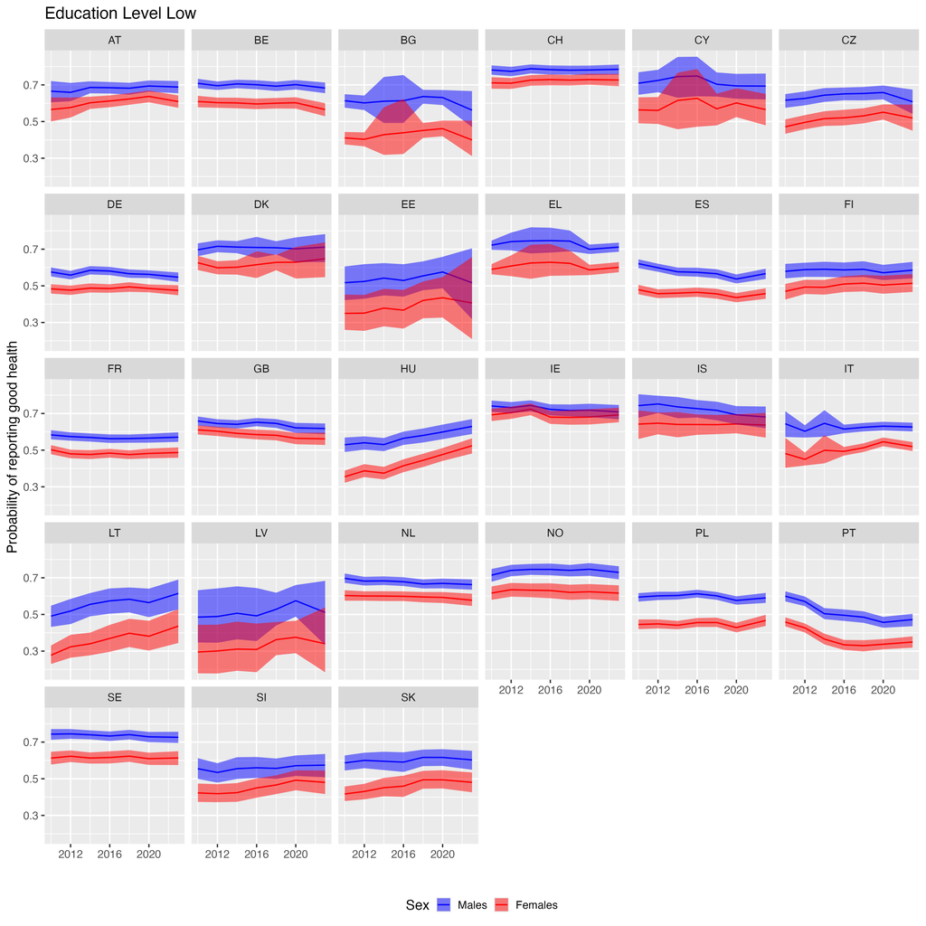

## Posterior probability of reporting good health

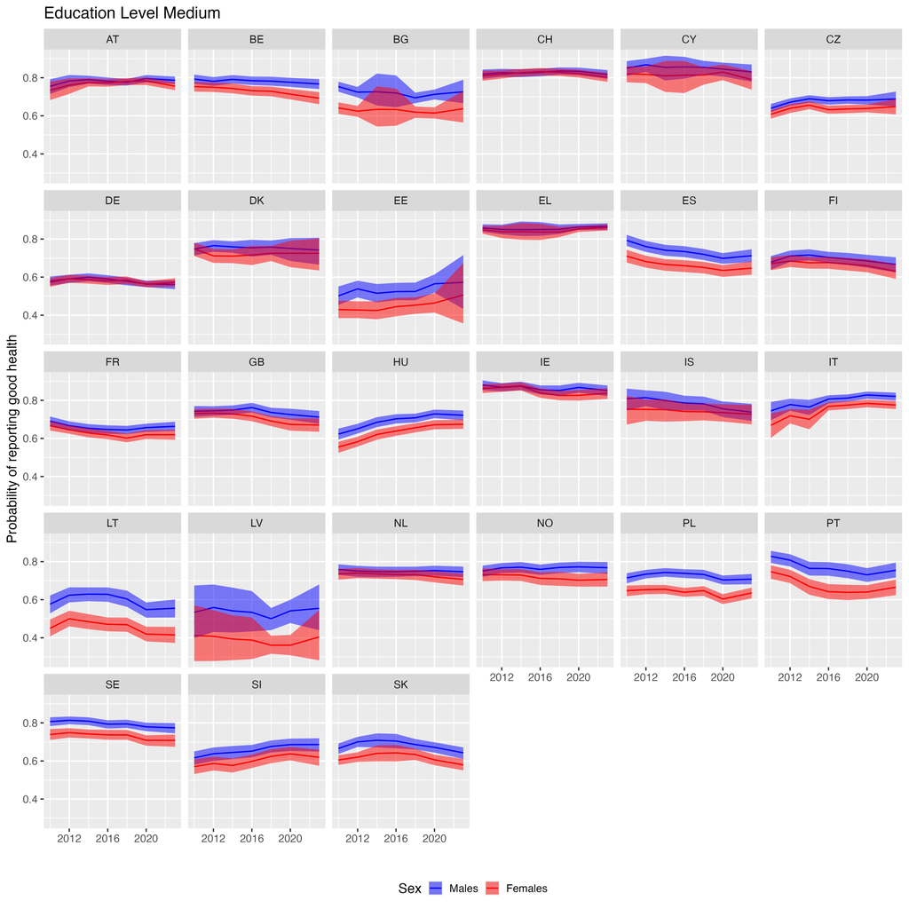

## Posterior probability of reporting good health

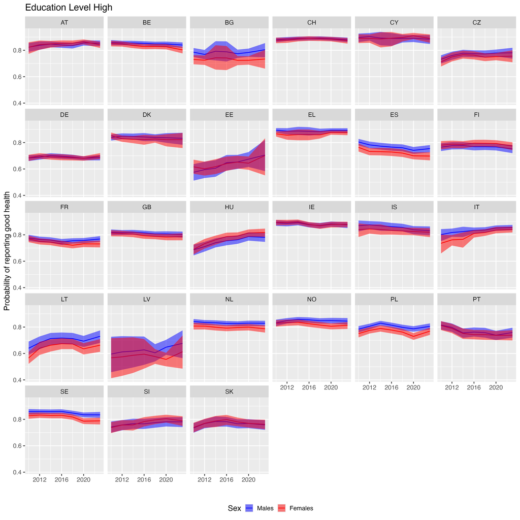